# Evergy Consuption of Electric Cars

# Entender o Problema

Uma empresa da área de transporte e logística deseja migrar sua frota para carros elétricos com o objetivo de reduzir os custos.

Antes de tomar a decisão, a empresa gostaria de prever o consumo de energia de carros elétricos com base em diversos fatores de utilização e características dos veículos.

Usando um dataset com dados reais disponíveis [publicamente](https://data.mendeley.com/datasets/tb9yrptydn/2), será construido um modelo de Machine Learning capaz de prever o consumo de energia de carros elétricos com base em diversos fatores, tais como o tipo e número de motores elétricos do veículo, o peso do veículo, a capacidade de carga, entre outros atributos.

Este conjunto de dados lista carros totalmente elétricos que, a partir de 2 de dezembro de 2020, poderiam ser adquiridos na Polônia como novos em uma concessionária autorizada e aqueles disponíveis em pré-venda pública e geral, mas somente se uma lista de preços disponível publicamente com versões de equipamentos e parâmetros técnicos completos estivesse disponível. com seus atributos

A coleção não contém dados sobre carros híbridos e carros elétricos dos chamados “extensores de alcance”. Os carros a hidrogênio também não foram incluídos no conjunto de dados devido ao número insuficiente de modelos produzidos em massa e à especificidade diferente (em comparação com veículo elétrico) do veículo, incluindo os diferentes métodos de carregamento.

O banco de dados composto por 53 carros elétricos (cada variante de um modelo – que difere em termos de capacidade da bateria, potência do motor etc. – é tratada separadamente) e 22 variáveis (25 variáveis, incluindo marca, modelo e “nome do carro” mesclando estes dois anteriores).

```r
library(readxl)
library(tidyverse)
library(moments)
library(corrplot)
library(vcd)
library(reshape2)
library(gridExtra)
library(car)
library(caret)
library(randomForest)
library(Boruta)
library(glmnet)
library(rpart)
library(randomForest)
library(e1071)
```

## Carregando os dados

```r
dados <- read_excel("data/FEV-data-Excel.xlsx", col_types = "guess")
```

# PASSO 01 - Descrição dos Dados

## 1.1 Renomear colunas

```r
colnames(dados) <- c('nomeCarro', 'marca', 'modelo', 'precoMinimoBrutoPLN', 'potenciaMotorKM', 'torqueMaximoNm', 'tipoFreios', 'tipoTracao', 'capacidadeBateriaKWh', 'autonomiaWLTPkm', 'distanciaEntreEixosCm', 'comprimentoCm', 'larguraCm', 'alturaCm', 'pesoMinimoVazioKg', 'pesoBrutoPermissivelKg', 'capacidadeMaximaCargaKg', 'numeroAssentos', 'numeroPortas', 'tamanhoPneuPol', 'velocidadeMaximaKmH', 'capacidadePortaMalasLitros', 'aceleracao0a100KmHS', 'potenciaMaximaCarregamentoDCKW', 'mediaConsumoEnergiaKWh100Km')

colnames(dados)
```

```
 [1] "nomeCarro"                      "marca"                          "modelo"                         "precoMinimoBrutoPLN"
 [5] "potenciaMotorKM"                "torqueMaximoNm"                 "tipoFreios"                     "tipoTracao"
 [9] "capacidadeBateriaKWh"           "autonomiaWLTPkm"                "distanciaEntreEixosCm"          "comprimentoCm"
[13] "larguraCm"                      "alturaCm"                       "pesoMinimoVazioKg"              "pesoBrutoPermissivelKg"
[17] "capacidadeMaximaCargaKg"        "numeroAssentos"                 "numeroPortas"                   "tamanhoPneuPol"
[21] "velocidadeMaximaKmH"            "capacidadePortaMalasLitros"     "aceleracao0a100KmHS"            "potenciaMaximaCarregamentoDCKW"
[25] "mediaConsumoEnergiaKWh100Km"
```

```r
# Vizualiza dos dados
head(dados)
```

| nomeCarro | marca | modelo | precoMinimoBrutoPLN | potenciaMotorKM | torqueMaximoNm | tipoFreios | tipoTracao | capacidadeBateriaKWh | autonomiaWLTPkm | distanciaEntreEixosCm | comprimentoCm | larguraCm | alturaCm | pesoMinimoVazioKg | pesoBrutoPermissivelKg | capacidadeMaximaCargaKg | numeroAssentos | numeroPortas | tamanhoPneuPol | velocidadeMaximaKmH | capacidadePortaMalasLitros | aceleracao0a100KmHS | potenciaMaximaCarregamentoDCKW | mediaConsumoEnergiaKWh100Km |
| --- | --- | --- | --- | --- | --- | --- | --- | --- | --- | --- | --- | --- | --- | --- | --- | --- | --- | --- | --- | --- | --- | --- | --- | --- |
| Audi e-tron 55 quattro | Audi | e-tron 55 quattro | 345700 | 360 | 664 | disc (front + rear) | 4WD | 95 | 438 | 292.8 | 490.1 | 193.5 | 162.9 | 2565 | 3130 | 640 | 5 | 5 | 19 | 200 | 660 | 5.7 | 150 | 24.45 |
| Audi e-tron 50 quattro | Audi | e-tron 50 quattro | 308400 | 313 | 540 | disc (front + rear) | 4WD | 71 | 340 | 292.8 | 490.1 | 193.5 | 162.9 | 2445 | 3040 | 670 | 5 | 5 | 19 | 190 | 660 | 6.8 | 150 | 23.80 |
| Audi e-tron S quattro | Audi | e-tron S quattro | 414900 | 503 | 973 | disc (front + rear) | 4WD | 95 | 364 | 292.8 | 490.2 | 197.6 | 162.9 | 2695 | 3130 | 565 | 5 | 5 | 20 | 210 | 660 | 4.5 | 150 | 27.55 |
| Audi e-tron Sportback 50 quattro | Audi | e-tron Sportback 50 quattro | 319700 | 313 | 540 | disc (front + rear) | 4WD | 71 | 346 | 292.8 | 490.1 | 193.5 | 161.6 | 2445 | 3040 | 640 | 5 | 5 | 19 | 190 | 615 | 6.8 | 150 | 23.30 |
| Audi e-tron Sportback 55 quattro | Audi | e-tron Sportback 55 quattro | 357000 | 360 | 664 | disc (front + rear) | 4WD | 95 | 447 | 292.8 | 490.1 | 193.5 | 161.6 | 2595 | 3130 | 670 | 5 | 5 | 19 | 200 | 615 | 5.7 | 150 | 23.85 |
| Audi e-tron Sportback S quattro | Audi | e-tron Sportback S quattro | 426200 | 503 | 973 | disc (front + rear) | 4WD | 95 | 369 | 292.8 | 490.2 | 197.6 | 161.5 | 2695 | 3130 | 565 | 5 | 5 | 20 | 210 | 615 | 4.5 | 150 | 27.20 |

## 1.2 Data Dimension

```r
print(paste("Number of rows ", nrow(dados)))
```

```
[1] "Number of rows  53"
```

```r
print(paste("Number of columns ", ncol(dados)))
```

```
[1] "Number of columns  25"
```

## 1.3 Data Types

```r
str(dados)
```

```
tibble [53 × 25] (S3: tbl_df/tbl/data.frame)
 $ nomeCarro                     : chr [1:53] "Audi e-tron 55 quattro" "Audi e-tron 50 quattro" "Audi e-tron S quattro" "Audi e-tron Sportback 50 quattro" ...
 $ marca                         : chr [1:53] "Audi" "Audi" "Audi" "Audi" ...
 $ modelo                        : chr [1:53] "e-tron 55 quattro" "e-tron 50 quattro" "e-tron S quattro" "e-tron Sportback 50 quattro" ...
 $ precoMinimoBrutoPLN           : num [1:53] 345700 308400 414900 319700 357000 ...
 $ potenciaMotorKM               : num [1:53] 360 313 503 313 360 503 170 184 286 136 ...
 $ torqueMaximoNm                : num [1:53] 664 540 973 540 664 973 250 270 400 260 ...
 $ tipoFreios                    : chr [1:53] "disc (front + rear)" "disc (front + rear)" "disc (front + rear)" "disc (front + rear)" ...
 $ tipoTracao                    : chr [1:53] "4WD" "4WD" "4WD" "4WD" ...
 $ capacidadeBateriaKWh          : num [1:53] 95 71 95 71 95 95 42.2 42.2 80 50 ...
 $ autonomiaWLTPkm               : num [1:53] 438 340 364 346 447 369 359 345 460 350 ...
 $ distanciaEntreEixosCm         : num [1:53] 293 293 293 293 293 ...
 $ comprimentoCm                 : num [1:53] 490 490 490 490 490 ...
 $ larguraCm                     : num [1:53] 194 194 198 194 194 ...
 $ alturaCm                      : num [1:53] 163 163 163 162 162 ...
 $ pesoMinimoVazioKg             : num [1:53] 2565 2445 2695 2445 2595 ...
 $ pesoBrutoPermissivelKg        : num [1:53] 3130 3040 3130 3040 3130 ...
 $ capacidadeMaximaCargaKg       : num [1:53] 640 670 565 640 670 565 440 440 540 459 ...
 $ numeroAssentos                : num [1:53] 5 5 5 5 5 5 4 4 5 5 ...
 $ numeroPortas                  : num [1:53] 5 5 5 5 5 5 5 5 5 5 ...
 $ tamanhoPneuPol                : num [1:53] 19 19 20 19 19 20 19 20 19 16 ...
 $ velocidadeMaximaKmH           : num [1:53] 200 190 210 190 200 210 160 160 180 150 ...
 $ capacidadePortaMalasLitros    : num [1:53] 660 660 660 615 615 615 260 260 510 380 ...
 $ aceleracao0a100KmHS           : num [1:53] 5.7 6.8 4.5 6.8 5.7 4.5 8.1 6.9 6.8 9.5 ...
 $ potenciaMaximaCarregamentoDCKW: num [1:53] 150 150 150 150 150 150 50 50 150 100 ...
 $ mediaConsumoEnergiaKWh100Km   : num [1:53] 24.4 23.8 27.6 23.3 23.9 ...
```

## 1.4 Check NAs

```r
# Contagem de linhas com dados completos
sum(complete.cases(dados))
```

```
[1] 42
```

```r
# Contagem de linhas com dados incompletos
sum(!complete.cases(dados))
```

```
[1] 11
```

```r
colSums(is.na(dados))
```

```
                     nomeCarro                          marca                         modelo            precoMinimoBrutoPLN
                             0                              0                              0                              0
               potenciaMotorKM                 torqueMaximoNm                     tipoFreios                     tipoTracao
                             0                              0                              1                              0
          capacidadeBateriaKWh                autonomiaWLTPkm          distanciaEntreEixosCm                  comprimentoCm
                             0                              0                              0                              0
                     larguraCm                       alturaCm              pesoMinimoVazioKg         pesoBrutoPermissivelKg
                             0                              0                              0                              8
       capacidadeMaximaCargaKg                 numeroAssentos                   numeroPortas                 tamanhoPneuPol
                             8                              0                              0                              0
           velocidadeMaximaKmH     capacidadePortaMalasLitros            aceleracao0a100KmHS potenciaMaximaCarregamentoDCKW
                             0                              1                              3                              0
   mediaConsumoEnergiaKWh100Km
                             9
```

## 1.4 Preencher NAs

Como o conjunto de dados é pequeno e 11 linhas não possuem dados completos, será feito imputation dos dados.

#### [Mercedes-Benz EQV (long)](https://www.ultimatespecs.com/car-specs/Mercedes-Benz/120227/Mercedes-Benz-EQV-300-Long.html)

- tipoFreios = disc (front + rear)
- aceleracao0a100KmHS = 12.1s
- capacidadePortaMalasLitros = 978.5

```r
dados[dados$nomeCarro == 'Mercedes-Benz EQV (long)', "tipoFreios"] <- "disc (front + rear)"
dados[dados$nomeCarro == 'Mercedes-Benz EQV (long)', "aceleracao0a100KmHS"] <- 12.1
dados[dados$nomeCarro == 'Mercedes-Benz EQV (long)', "capacidadePortaMalasLitros"] <- 978.5
```

#### [Tesla Model 3 Standard Range Plus](https://ev-database.org/car/1485/Tesla-Model-3-Standard-Range-Plus)

- capacidadeMaximaCargaKg = 389 kg
- pesoBrutoPermissivelKg = 2014 kg
- mediaConsumoEnergiaKWh100Km = 14.6 kWh/100 km

```r
dados[dados$nomeCarro == 'Tesla Model 3 Standard Range Plus', "capacidadeMaximaCargaKg"] <- 389
dados[dados$nomeCarro == 'Tesla Model 3 Standard Range Plus', "pesoBrutoPermissivelKg"] <- 2014
dados[dados$nomeCarro == 'Tesla Model 3 Standard Range Plus', "mediaConsumoEnergiaKWh100Km"] <- 14.6
```

#### [Peugeot-e-2008](https://ev-database.org/car/1206/Peugeot-e-2008-SUV)

```r
dados[dados$nomeCarro == 'Peugeot e-2008', "capacidadeMaximaCargaKg"] <- 389
dados[dados$nomeCarro == 'Peugeot e-2008', "pesoBrutoPermissivelKg"] <- 2030
dados[dados$nomeCarro == 'Peugeot e-2008', "aceleracao0a100KmHS"] <- 8.5
dados[dados$nomeCarro == 'Peugeot e-2008', "mediaConsumoEnergiaKWh100Km"] <- 18.2
```

#### [Citroën ë-C4](https://ev-database.org/car/1587/Citroen-e-C4)

- mediaConsumoEnergiaKWh100Km = 16.8 kWh/100 km

```r
dados[dados$nomeCarro == 'Citroën ë-C4', "mediaConsumoEnergiaKWh100Km"]  <- 16.8
```

#### [Tesla Model 3 Long Range](https://ev-database.org/car/1591/Tesla-Model-3-Long-Range-Dual-Motor)

- capacidadeMaximaCargaKg = 388 kg
- pesoBrutoPermissivelKg = 2232 -mediaConsumoEnergiaKWh100Km = 15,5 kWh/100 km

```r
dados[dados$nomeCarro == "Tesla Model 3 Long Range", "capacidadeMaximaCargaKg"] <- 388
dados[dados$nomeCarro == "Tesla Model 3 Long Range", "pesoBrutoPermissivelKg"] <- 2232
dados[dados$nomeCarro == "Tesla Model 3 Long Range", "mediaConsumoEnergiaKWh100Km"] <- 15.5
```

#### [Tesla Model 3 Performance](https://ev-database.org/car/1620/Tesla-Model-3-Performance)

- capacidadeMaximaCargaKg = 388 kg
- pesoBrutoPermissivelKg = 2232
- mediaConsumoEnergiaKWh100Km = 16,3 kWh/100 km

```r
dados[dados$nomeCarro == "Tesla Model 3 Performance", "capacidadeMaximaCargaKg"] <- 388
dados[dados$nomeCarro == "Tesla Model 3 Performance", "pesoBrutoPermissivelKg"] <- 2232
dados[dados$nomeCarro == "Tesla Model 3 Performance", "mediaConsumoEnergiaKWh100Km"] <- 16.3
```

#### [Tesla Model S Long Range Plus](https://ev-database.org/car/1323/Tesla-Model-S-Long-Range-Plus)

- capacidadeMaximaCargaKg = 394 kg
- pesoBrutoPermissivelKg = 2574 kg
- mediaConsumoEnergiaKWh100Km = 17,7 kWh/100 km

```r
dados[dados$nomeCarro == "Tesla Model S Long Range Plus", "capacidadeMaximaCargaKg"] <- 394
dados[dados$nomeCarro == "Tesla Model S Long Range Plus", "pesoBrutoPermissivelKg"] <- 2574
dados[dados$nomeCarro == "Tesla Model S Long Range Plus", "mediaConsumoEnergiaKWh100Km"] <- 17.7
```

#### [Tesla Model S Performance](https://ev-database.org/car/1324/Tesla-Model-S-Performance)

- capacidadeMaximaCargaKg = 394 kg
- pesoBrutoPermissivelKg = 2626 kg
- mediaConsumoEnergiaKWh100Km = 18,3 kWh/100 km

```r
dados[dados$nomeCarro == "Tesla Model S Performance", "capacidadeMaximaCargaKg"] <- 394
dados[dados$nomeCarro == "Tesla Model S Performance", "pesoBrutoPermissivelKg"] <- 2626
dados[dados$nomeCarro == "Tesla Model S Performance", "mediaConsumoEnergiaKWh100Km"] <- 18.3
```

#### [Tesla Model X Long Range Plus](https://ev-database.org/car/1325/Tesla-Model-X-Long-Range-Plus)

- capacidadeMaximaCargaKg = 610 kg
- pesoBrutoPermissivelKg = 3040 kg
- mediaConsumoEnergiaKWh100Km = 20,4 kWh/100 km

```r
dados[dados$nomeCarro == "Tesla Model X Long Range Plus", "capacidadeMaximaCargaKg"] <- 610
dados[dados$nomeCarro == "Tesla Model X Long Range Plus", "pesoBrutoPermissivelKg"] <- 3040
dados[dados$nomeCarro == "Tesla Model X Long Range Plus", "mediaConsumoEnergiaKWh100Km"] <- 20.4
```

#### [Tesla Model X Performance](https://ev-database.org/car/1326/Tesla-Model-X-Performance)

- capacidadeMaximaCargaKg = 610 kg
- pesoBrutoPermissivelKg = 3087 kg
- mediaConsumoEnergiaKWh100Km = 20,9 kWh/100 km

```r
dados[dados$nomeCarro == "Tesla Model X Performance", "capacidadeMaximaCargaKg"] <- 610
dados[dados$nomeCarro == "Tesla Model X Performance", "pesoBrutoPermissivelKg"] <- 3087
dados[dados$nomeCarro == "Tesla Model X Performance", "mediaConsumoEnergiaKWh100Km"] <- 20.9
```

#### [Nissan e-NV200 evalia](https://ev-database.org/car/1117/Nissan-e-NV200-Evalia)

- aceleracao0a100KmHS = 14.0s

```r
dados[dados$nomeCarro == "Nissan e-NV200 evalia", "aceleracao0a100KmHS"] <- 14.0
```

```r
# Contagem de linhas com dados incompletos
sum(!complete.cases(dados))
```

```
[1] 0
```

## 1.7 Estatísticas descritivas

### 1.7.1 Atributos Numericos

```r
get_descriptive_analysis <- function(dados){

mean <- apply(dados, 2, mean, na.rm = TRUE)
std <- apply(dados, 2, sd, na.rm = TRUE)
min <- apply(dados, 2, min, na.rm = TRUE)
max <- apply(dados, 2, max, na.rm = TRUE)
median <- apply(dados, 2, median, na.rm = TRUE)
quartis <- apply(dados, 2, quantile, probs = c(0.25, 0.75), na.rm = TRUE)
IQR <- apply(dados, 2, IQR, na.rm = TRUE)
skew <- apply(dados, 2, skewness, na.rm = TRUE)
kurtosis <- apply(dados, 2, kurtosis, na.rm = TRUE)

result <- data.frame(min, max, max-min, mean, median, std, skew, kurtosis)


names(result) <- c("min", "max", "range", "mean", "median", "std", "skew", "kurtosis")

return(result)
}

get_descriptive_analysis(dados %>% select_if(is.numeric))
```

|  | min | max | range | mean | median | std | skew | kurtosis |
| --- | --- | --- | --- | --- | --- | --- | --- | --- |
| precoMinimoBrutoPLN | 82050.0 | 794000.0 | 711950.0 | 2.461585e+05 | 178400.0 | 1.491875e+05 | 1.47946765 | 2.14890348 |
| potenciaMotorKM | 82.0 | 772.0 | 690.0 | 2.697736e+02 | 204.0 | 1.812986e+02 | 1.13421026 | 0.33326006 |
| torqueMaximoNm | 160.0 | 1140.0 | 980.0 | 4.600377e+02 | 362.0 | 2.616470e+02 | 1.11745460 | 0.20238904 |
| capacidadeBateriaKWh | 17.6 | 100.0 | 82.4 | 6.236604e+01 | 58.0 | 2.417091e+01 | 0.11533262 | -1.27237589 |
| autonomiaWLTPkm | 148.0 | 652.0 | 504.0 | 3.769057e+02 | 364.0 | 1.188179e+02 | 0.23970997 | -0.45082918 |
| distanciaEntreEixosCm | 187.3 | 327.5 | 140.2 | 2.735811e+02 | 270.0 | 2.274052e+01 | -0.65994872 | 2.30382343 |
| comprimentoCm | 269.5 | 514.0 | 244.5 | 4.425094e+02 | 447.0 | 4.886328e+01 | -0.88312112 | 1.13198608 |
| larguraCm | 164.5 | 255.8 | 91.3 | 1.862415e+02 | 180.9 | 1.428064e+01 | 2.06780092 | 8.27541700 |
| alturaCm | 137.8 | 191.0 | 53.2 | 1.554226e+02 | 155.6 | 1.127536e+01 | 1.10942569 | 2.20366304 |
| pesoMinimoVazioKg | 1035.0 | 2710.0 | 1675.0 | 1.868453e+03 | 1685.0 | 4.708809e+02 | 0.32751414 | -1.24728446 |

[output cut: 10 more lines]

### 1.7.1 Atributos Categoricos

```r
# Selecionar as variáveis categóricas
names(select(dados, where(is.character) | where(is.factor)))
```

```
[1] "nomeCarro"  "marca"      "modelo"     "tipoFreios" "tipoTracao"
```

As variáveis nomeCarro, modelo e marca serão desconsideradas durante a análise. Muitas marcas possuem apenas uma amostra na base de dados.

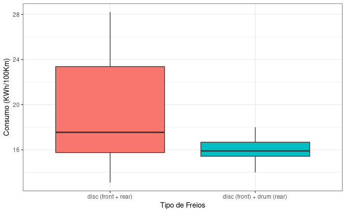

```r
ggplot(dados, aes(x = tipoFreios, y = mediaConsumoEnergiaKWh100Km, fill=tipoFreios )) +
     geom_boxplot() +
     xlab("Tipo de Freios") +
     ylab("Consumo (KWh/100Km)") +
     theme_bw() +
     theme(legend.position = "none")
```

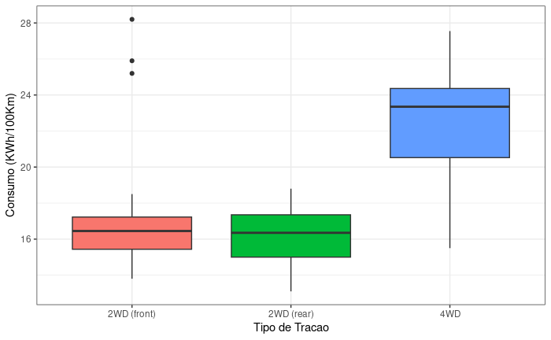

```r
ggplot(dados, aes(x = tipoTracao, y = mediaConsumoEnergiaKWh100Km, fill=tipoTracao)) +
     geom_boxplot() +
     xlab("Tipo de Tracao") +
     ylab("Consumo (KWh/100Km)") +
     theme_bw() +
     theme(legend.position = "none")
```

# PASSO 02 - Seleção da Colunas

```r
# Remover colunas pelo nome
dados <- subset(dados, select = -c(nomeCarro, marca, modelo))

# Exibir as colunas do data frame resultante
colnames(dados)
```

```
 [1] "precoMinimoBrutoPLN"            "potenciaMotorKM"                "torqueMaximoNm"                 "tipoFreios"
 [5] "tipoTracao"                     "capacidadeBateriaKWh"           "autonomiaWLTPkm"                "distanciaEntreEixosCm"
 [9] "comprimentoCm"                  "larguraCm"                      "alturaCm"                       "pesoMinimoVazioKg"
[13] "pesoBrutoPermissivelKg"         "capacidadeMaximaCargaKg"        "numeroAssentos"                 "numeroPortas"
[17] "tamanhoPneuPol"                 "velocidadeMaximaKmH"            "capacidadePortaMalasLitros"     "aceleracao0a100KmHS"
[21] "potenciaMaximaCarregamentoDCKW" "mediaConsumoEnergiaKWh100Km"
```

```r
# Transformar variáveis categóricas em fatores
dados$tipoFreios <- as.factor(dados$tipoFreios)
dados$tipoTracao <- as.factor(dados$tipoTracao)
str(dados)
```

```
tibble [53 × 22] (S3: tbl_df/tbl/data.frame)
 $ precoMinimoBrutoPLN           : num [1:53] 345700 308400 414900 319700 357000 ...
 $ potenciaMotorKM               : num [1:53] 360 313 503 313 360 503 170 184 286 136 ...
 $ torqueMaximoNm                : num [1:53] 664 540 973 540 664 973 250 270 400 260 ...
 $ tipoFreios                    : Factor w/ 2 levels "disc (front + rear)",..: 1 1 1 1 1 1 1 1 1 1 ...
 $ tipoTracao                    : Factor w/ 3 levels "2WD (front)",..: 3 3 3 3 3 3 2 2 2 1 ...
 $ capacidadeBateriaKWh          : num [1:53] 95 71 95 71 95 95 42.2 42.2 80 50 ...
 $ autonomiaWLTPkm               : num [1:53] 438 340 364 346 447 369 359 345 460 350 ...
 $ distanciaEntreEixosCm         : num [1:53] 293 293 293 293 293 ...
 $ comprimentoCm                 : num [1:53] 490 490 490 490 490 ...
 $ larguraCm                     : num [1:53] 194 194 198 194 194 ...
 $ alturaCm                      : num [1:53] 163 163 163 162 162 ...
 $ pesoMinimoVazioKg             : num [1:53] 2565 2445 2695 2445 2595 ...
 $ pesoBrutoPermissivelKg        : num [1:53] 3130 3040 3130 3040 3130 ...
 $ capacidadeMaximaCargaKg       : num [1:53] 640 670 565 640 670 565 440 440 540 459 ...
 $ numeroAssentos                : num [1:53] 5 5 5 5 5 5 4 4 5 5 ...
 $ numeroPortas                  : num [1:53] 5 5 5 5 5 5 5 5 5 5 ...
 $ tamanhoPneuPol                : num [1:53] 19 19 20 19 19 20 19 20 19 16 ...
 $ velocidadeMaximaKmH           : num [1:53] 200 190 210 190 200 210 160 160 180 150 ...
 $ capacidadePortaMalasLitros    : num [1:53] 660 660 660 615 615 615 260 260 510 380 ...
 $ aceleracao0a100KmHS           : num [1:53] 5.7 6.8 4.5 6.8 5.7 4.5 8.1 6.9 6.8 9.5 ...
 $ potenciaMaximaCarregamentoDCKW: num [1:53] 150 150 150 150 150 150 50 50 150 100 ...
 $ mediaConsumoEnergiaKWh100Km   : num [1:53] 24.4 23.8 27.6 23.3 23.9 ...
```

# Passo 3 - Análise Exploratória dos dados

Como há poucas amostras no conjunto de dados a separação dos dados de treino e teste será realizada após a a analse exploratória dos dados.

## 3.1 Análise Univariada

### 3.1.1 Variável Resposta

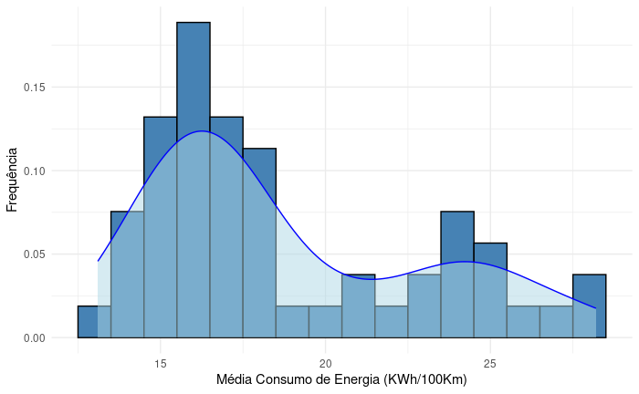

```r
# Crie o histograma com curva de densidade usando ggplot2
ggplot(data = dados, aes(x = mediaConsumoEnergiaKWh100Km)) +
  geom_histogram(aes(y = after_stat(density)), binwidth = 1, fill = "steelblue", color = "black") +
  geom_density(fill = "lightblue", alpha = 0.5, color = "blue") +
  labs(x = "Média Consumo de Energia (KWh/100Km)", y = "Frequência") +
  theme_minimal()
```

### 3.1.2 Variaveis Numéricas

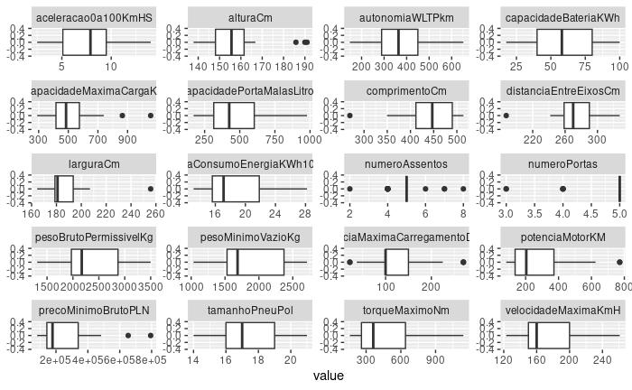

```r
# Plotando boxplots para cada variável numérica em um único gráfico
dados %>% select_if(is.numeric) %>%
  gather(variable, value ) %>%
  ggplot( aes(x=value)) +
  geom_boxplot() +
  facet_wrap(~ variable, ncol = 4, scales = "free")
```

```r
# Verificar quais colunas têm valores discrepantes (outliers)
outliers <- apply(dados %>% select_if(is.numeric), 2, function(x) any(boxplot.stats(x)$out))
outliers
```

```
           precoMinimoBrutoPLN                potenciaMotorKM                 torqueMaximoNm           capacidadeBateriaKWh
                          TRUE                           TRUE                          FALSE                          FALSE
               autonomiaWLTPkm          distanciaEntreEixosCm                  comprimentoCm                      larguraCm
                         FALSE                           TRUE                           TRUE                           TRUE
                      alturaCm              pesoMinimoVazioKg         pesoBrutoPermissivelKg        capacidadeMaximaCargaKg
                          TRUE                          FALSE                          FALSE                           TRUE
                numeroAssentos                   numeroPortas                 tamanhoPneuPol            velocidadeMaximaKmH
                          TRUE                           TRUE                          FALSE                          FALSE
    capacidadePortaMalasLitros            aceleracao0a100KmHS potenciaMaximaCarregamentoDCKW    mediaConsumoEnergiaKWh100Km
                         FALSE                          FALSE                           TRUE                          FALSE
```

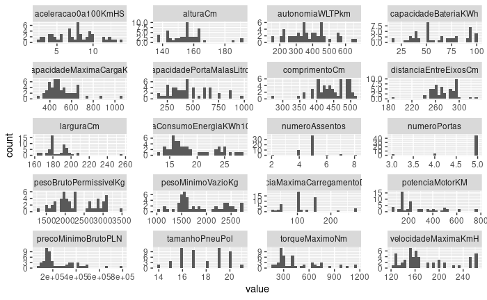

```r
# Plotando histogramas para cada variável numérica em um único gráfico
dados %>% select_if(is.numeric) %>%
  gather(variable, value) %>%
  ggplot( aes(x=value)) +
  geom_histogram() +
  facet_wrap(~ variable, ncol = 4, scales = "free")
```

```r
# Define a estrutura da figura
par(mar = c(2, 2, 2, 2))  # Definir margens menores
layout(matrix(1:20, 5, 4, byrow = TRUE))

# Inicializar a lista para salvar os valores-p
p_values <- list()


for (coluna in colnames(dados)) {
  if (is.numeric(dados[[coluna]])) {
    # Gerar o qqplot para a coluna numérica

    # qqPlot(dados[[coluna]], ylab = coluna)

    # Calcular o valor-p para o teste de normalidade
    shapiro <- shapiro.test(dados[[coluna]])
    p_value <- shapiro$p.value

    # Adicionar o valor-p à lista
    p_values[[coluna]] <- p_value
  }
}



as.data.frame(p_values) %>%
  gather(variable, 'p_value' ) %>%
  mutate(rejeitou_H0 = p_value < 0.05)
```

| variable | p_value | rejeitou_H0 |
| --- | --- | --- |
| precoMinimoBrutoPLN | 2.171747e-06 | TRUE |
| potenciaMotorKM | 4.431479e-06 | TRUE |
| torqueMaximoNm | 7.000158e-06 | TRUE |
| capacidadeBateriaKWh | 5.186537e-03 | TRUE |
| autonomiaWLTPkm | 6.546809e-01 | FALSE |
| distanciaEntreEixosCm | 2.016518e-03 | TRUE |
| comprimentoCm | 3.632577e-03 | TRUE |
| larguraCm | 1.139571e-06 | TRUE |
| alturaCm | 8.876149e-05 | TRUE |
| pesoMinimoVazioKg | 8.702493e-04 | TRUE |

[output cut: 10 more lines]

```r
rm(p_values, p_value, shapiro, coluna)
```

Apenas as variáveis autonomiaWLTPkm e aceleracao0a100KmHS possuem evidências suficientes para não rejeitarem a hipótese nula de que as suas distribuições são normais.

### 3.1.3 Variáveis Categóricas

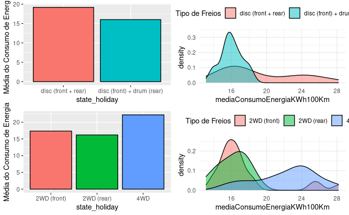

```r
# Criar o gráfico de barras com ggplot2
p1 <- ggplot(data = dados, aes(x = tipoFreios, y = mediaConsumoEnergiaKWh100Km, fill = tipoFreios)) +
  geom_bar(stat = "summary", fun = "mean", color = "black") +
  labs(x = "state_holiday", y = "Média do Consumo de Energia") +
  theme(legend.position = "none")

# Criação do gráfico de densidade
p2 <- ggplot(dados, aes(x = mediaConsumoEnergiaKWh100Km, fill = tipoFreios)) +
  geom_density(alpha = 0.5) +
  scale_fill_discrete(name = "Tipo de Freios") +
  theme_minimal() +
  theme(legend.position = "top")

# Criar o gráfico de barras com ggplot2
p3 <- ggplot(data = dados, aes(x = tipoTracao, y = mediaConsumoEnergiaKWh100Km, fill = tipoTracao)) +
  geom_bar(stat = "summary", fun = "mean", color = "black") +
  labs(x = "state_holiday", y = "Média do Consumo de Energia") +
  theme(legend.position = "none")

# Criação do gráfico de densidade
p4 <- ggplot(dados, aes(x = mediaConsumoEnergiaKWh100Km, fill = tipoTracao)) +
  geom_density(alpha = 0.5) +
  scale_fill_discrete(name = "Tipo de Freios") +
  theme_minimal() +
  theme(legend.position = "top")


# Organização dos subplots lado a lado
grid.arrange(p1, p2, p3, p4, ncol = 2)
```

```r
rm(p1 ,p2 ,p3 , p4)
```

## 3.2 Análise Multivariada

### 3.2.1 Variáveis Numericas

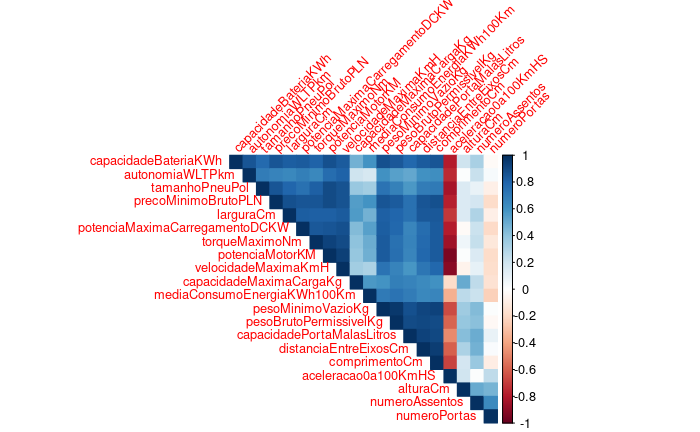

```r
# Explorando relacionamento entre as variáveis: Matriz de Correlação - corrplot
corrplot(cor(dados %>% select_if(is.numeric), method = "spearman"), method = "color", type = "upper", order = "hclust", tl.cex = 0.8, tl.srt = 45)
```

### 3.2.2 Variáveis Categoricas

```r
assocstats(table(dados$tipoTracao, dados$tipoFreios))
```

```
                    X^2 df  P(> X^2)
Likelihood Ratio 12.447  2 0.0019824
Pearson          13.215  2 0.0013501

Phi-Coefficient   : NA
Contingency Coeff.: 0.447
Cramer's V        : 0.499
```

Valor-p: O valor-p associado ao teste de qui-quadrado é menor que 0,05 (p < 0,05). Isso indica que há evidências estatísticas para rejeitar a hipótese nula de que não há associação entre as variáveis “tipoTracao” e “tipoFreios”. Em outras palavras, existe uma associação significativa entre essas variáveis.

Coeficiente de Cramér-V: O coeficiente de Cramér-V é uma medida de associação entre variáveis categóricas. No caso, o valor de Cramér’s V é 0,499. Esse valor varia de 0 a 1, onde 0 indica nenhuma associação e 1 indica associação completa. Um valor de 0,499 sugere uma associação moderada entre as variáveis “tipoTracao” e “tipoFreios”.

## 3.3 Análise Bivariada

#### Hipótese 1: Carros que possuem menor tempo de aceleração de 0 a 100Km/h possuem menor media de consumo de Energia. Qual a correlação entre essas duas variáveis?

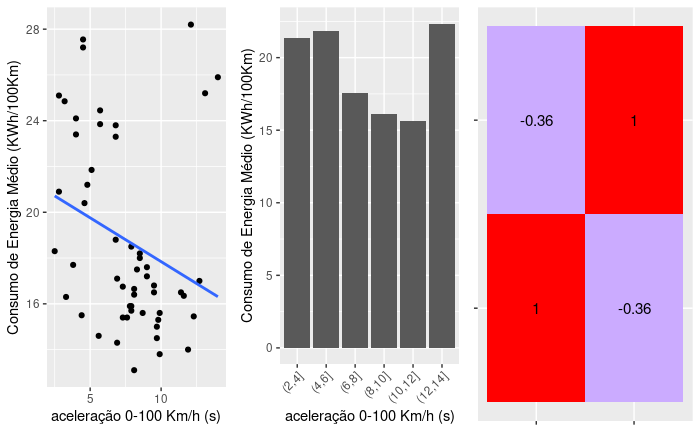

```r
# Primeiro subplot: scatterplot
p1 <- ggplot(dados, aes(x = aceleracao0a100KmHS, y = mediaConsumoEnergiaKWh100Km)) +
  geom_point() +
  geom_smooth(method = "lm", se = FALSE) +
  labs(x = "aceleração 0-100 Km/h (s)", y = "Consumo de Energia Médio (KWh/100Km)")

# Segundo subplot: barplot
cuts <- seq(floor(min(dados$aceleracao0a100KmHS)), ceiling(max(dados$aceleracao0a100KmHS)), length.out = 7)

dados$aceleracao0a100KmHS_binned  <- cut(dados$aceleracao0a100KmHS, breaks = cuts, order_result = ordered)

p2 <- dados %>%
  group_by(aceleracao0a100KmHS_binned) %>%
  summarise(media_ConsumoEnergia = mean(mediaConsumoEnergiaKWh100Km)) %>%
    ggplot( aes(x = aceleracao0a100KmHS_binned, y = media_ConsumoEnergia)) +
    geom_bar(stat = "identity") +
    labs(x = "aceleração 0-100 Km/h (s)", y = "Consumo de Energia Médio (KWh/100Km)") +
    theme(axis.text.x = element_text(angle = 45, hjust = 1))

# Terceiro subplot: heatmap de correlação
cor_mat <- cor(dados %>% select(aceleracao0a100KmHS, mediaConsumoEnergiaKWh100Km), method = "spearman")

# Transforme a matriz de correlação em um data.frame
cor_df <- melt(cor_mat)

# Plot a matriz de correlação como um gráfico de azulejos
p3 <- ggplot(cor_df, aes(x = Var1, y = Var2, fill = value)) +
  geom_tile() +
  geom_text(aes(label = round(value, digits = 2)), color = "black", size = 4) + # Adiciona rótulos
  scale_fill_gradient2(low = "blue", mid = "white", high = "red", midpoint = 0) +
  theme(axis.text.x = element_blank(),  # Oculta os rótulos do eixo x
        axis.text.y = element_blank(),  # Oculta os rótulos do eixo y
        axis.title.x = element_blank(), # Oculta o título do eixo x
        axis.title.y = element_blank(), # Oculta o título do eixo y
        legend.position = "none") +
  theme(legend.position = "none")




# Organização dos subplots lado a lado
grid.arrange(p1, p2, p3, ncol = 3)
```

```r
dados <- subset(dados, select = -aceleracao0a100KmHS_binned)
rm(cuts, p1 ,p2 ,p3 , cor_mat, cor_df)
```

De acordo com os gráficos o coeficiente de correlação é ligeiramente negativo, indicando que há uma correlação negativa fraca entre as variáveis. Isso significa que, à medida que o tempo de aceleração de 0 a 100Km/h aumenta, o consumo medio de Energia tende a diminuir, mas a relação não é muito forte.

#### Hipótese 2: Carros que possuem maior peso bruto permissivel possuem maior media de consumo de energia. Qual a correlação entre essas duas variáveis?

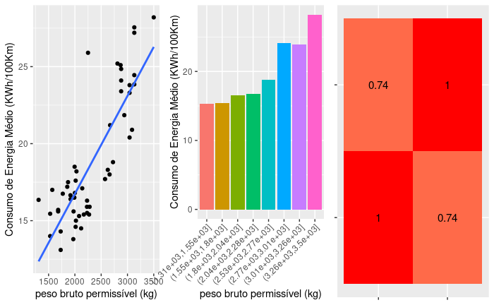

```r
# Primeiro subplot: scatterplot
p1 <- ggplot(dados, aes(x = pesoBrutoPermissivelKg, y = mediaConsumoEnergiaKWh100Km)) +
  geom_point() +
  geom_smooth(method = "lm", se = FALSE) +
  labs(x = "peso bruto permissível (kg)", y = "Consumo de Energia Médio (KWh/100Km)")

# Segundo subplot: barplot
cuts <- seq(floor(min(dados$pesoBrutoPermissivelKg)-1), ceiling(max(dados$pesoBrutoPermissivelKg)), length.out = 10)

dados$pesoBrutoPermissivelKg_binned  <- cut(dados$pesoBrutoPermissivelKg, breaks = cuts, order_result = ordered)

p2 <- dados %>%
  group_by(pesoBrutoPermissivelKg_binned) %>%
  summarise(media_ConsumoEnergia = mean(mediaConsumoEnergiaKWh100Km)) %>%
    ggplot( aes(x = pesoBrutoPermissivelKg_binned, y = media_ConsumoEnergia, fill=pesoBrutoPermissivelKg_binned)) +
    geom_bar(stat = "identity") +
    labs(x = "peso bruto permissível (kg)", y = "Consumo de Energia Médio (KWh/100Km)") +
    theme(axis.text.x = element_text(angle = 45, hjust = 1), legend.position = "none")


# Terceiro subplot: heatmap de correlação
cor_mat <- cor(dados %>% select(pesoBrutoPermissivelKg, mediaConsumoEnergiaKWh100Km), method = "spearman")

# Transforme a matriz de correlação em um data.frame
cor_df <- melt(cor_mat)

# Plot a matriz de correlação como um gráfico de azulejos
p3 <- ggplot(cor_df, aes(x = Var1, y = Var2, fill = value)) +
  geom_tile() +
  geom_text(aes(label = round(value, digits = 2)), color = "black", size = 4) + # Adiciona rótulos
  scale_fill_gradient2(low = "blue", mid = "white", high = "red", midpoint = 0) +
  theme(axis.text.x = element_blank(),  # Oculta os rótulos do eixo x
        axis.text.y = element_blank(),  # Oculta os rótulos do eixo y
        axis.title.x = element_blank(), # Oculta o título do eixo x
        axis.title.y = element_blank(), # Oculta o título do eixo y
        legend.position = "none")



# Combine os subplots em uma única plotagem usando a função cowplot::plot_grid
# Organização dos subplots lado a lado
grid.arrange(p1, p2, p3, ncol = 3)
```

```r
dados <- subset(dados, select = -pesoBrutoPermissivelKg_binned)
rm(cuts, p1 ,p2 ,p3 , cor_mat, cor_df)
```

De acordo com os gráficos o coeficiente de correlação é positivo. Isso significa que, à medida que o peso bruto permissivel aumenta, o consumo medio de energia tende a aumentar.

#### Hipótese 3: Carros que possuem maior autonomia (km) possuem menor media de consumo de Energia (KWh/100km). Qual a correlação entre essas duas variáveis?

```r
# Cálculo do coeficiente de correlação e valor-p
print(cor.test(dados$autonomiaWLTPkm, dados$mediaConsumoEnergiaKWh100Km, method = "kendall"))
```

```
    Kendall's rank correlation tau

data:  dados$autonomiaWLTPkm and dados$mediaConsumoEnergiaKWh100Km
z = 0.98981, p-value = 0.3223
alternative hypothesis: true tau is not equal to 0
sample estimates:
       tau
0.09395487
```

Inconclusivo. Como o valor p retornado é maior que 0.05, então a hipótese nula não pode ser rejeitada. Em outras palavras, não há evidências estatísticas suficientes para suportar a hipótese alternativa de que existe uma correlação significativa entre a autonomia e o consumo de energia.

#### Hipótese 4: Carros elétricos mais caros possuam uma maior média de consumo de energia. Qual a correlação entre essas duas variáveis?

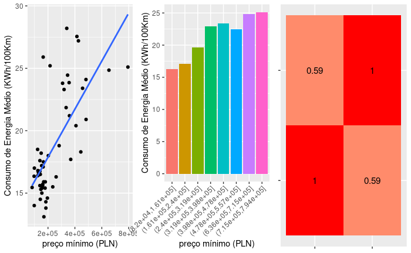

```r
# Primeiro subplot: scatterplot
p1 <- ggplot(dados, aes(x = precoMinimoBrutoPLN, y = mediaConsumoEnergiaKWh100Km)) +
  geom_point() +
  geom_smooth(method = "lm", se = FALSE) +
  labs(x = "preço mínimo (PLN)", y = "Consumo de Energia Médio (KWh/100Km)")

# Segundo subplot: barplot
cuts <- seq(floor(min(dados$precoMinimoBrutoPLN)-1), ceiling(max(dados$precoMinimoBrutoPLN)), length.out = 10)

dados$precoMinimoBrutoPLN_binned  <- cut(dados$precoMinimoBrutoPLN, breaks = cuts, order_result = ordered)

p2 <- dados %>%
  group_by(precoMinimoBrutoPLN_binned) %>%
  summarise(media_ConsumoEnergia = mean(mediaConsumoEnergiaKWh100Km)) %>%
    ggplot( aes(x = precoMinimoBrutoPLN_binned, y = media_ConsumoEnergia, fill=precoMinimoBrutoPLN_binned)) +
    geom_bar(stat = "identity") +
    labs(x = "preço mínimo (PLN)", y = "Consumo de Energia Médio (KWh/100Km)") +
    theme(axis.text.x = element_text(angle = 45, hjust = 1), legend.position = "none")


# Terceiro subplot: heatmap de correlação
cor_mat <- cor(dados %>% select(precoMinimoBrutoPLN, mediaConsumoEnergiaKWh100Km), method = "spearman")

# Transforme a matriz de correlação em um data.frame
cor_df <- melt(cor_mat)

# Plot a matriz de correlação como um gráfico de azulejos
p3 <- ggplot(cor_df, aes(x = Var1, y = Var2, fill = value)) +
  geom_tile() +
  geom_text(aes(label = round(value, digits = 2)), color = "black", size = 4) + # Adiciona rótulos
  scale_fill_gradient2(low = "blue", mid = "white", high = "red", midpoint = 0) +
  theme(axis.text.x = element_blank(),  # Oculta os rótulos do eixo x
        axis.text.y = element_blank(),  # Oculta os rótulos do eixo y
        axis.title.x = element_blank(), # Oculta o título do eixo x
        axis.title.y = element_blank(), # Oculta o título do eixo y
        legend.position = "none")



# Combine os subplots em uma única plotagem usando a função cowplot::plot_grid
# Organização dos subplots lado a lado
grid.arrange(p1, p2, p3, ncol = 3)
```

```r
dados <- subset(dados, select = -precoMinimoBrutoPLN_binned)
rm(cuts, p1 ,p2 ,p3 , cor_mat, cor_df)
```

De acordo com os gráficos o coeficiente de correlação é positivo. Isso significa que, à medida que o valor de uma variável aumenta, o valor da outra variável tende a aumentar.

O teste ANOVA é usado para comparar as médias de grupos diferentes e determinar se há diferenças significativas entre eles.

As premissas do teste ANOVA são as seguintes:

1. Independência: As observações devem ser independentes umas das outras. Isso significa que os valores em uma condição não devem ser influenciados pelos valores em outras condições.
2. Normalidade: As distribuições dos dados dentro de cada grupo devem ser aproximadamente normais. Isso significa que os resíduos do modelo devem seguir uma distribuição normal.
3. Homogeneidade das variâncias: As variâncias dos grupos devem ser aproximadamente iguais. Isso significa que a variabilidade dos dados deve ser semelhante em cada grupo.

Sera considerada verdadeira a premissa 1.

```r
# Teste de Normalidade Shapiro-Wilk em cada grupo de tração
# H0: Os dados são normalmente distribuídos
# H1: Os dados não são normalmente distribuídos

print(shapiro.test(dados$mediaConsumoEnergiaKWh100Km[dados$tipoTracao == '2WD (front)']) )
```

```
    Shapiro-Wilk normality test

data:  dados$mediaConsumoEnergiaKWh100Km[dados$tipoTracao == "2WD (front)"]
W = 0.70614, p-value = 1.216e-05
```

```r
print(shapiro.test(dados$mediaConsumoEnergiaKWh100Km[dados$tipoTracao == '2WD (rear)']) )
```

```
    Shapiro-Wilk normality test

data:  dados$mediaConsumoEnergiaKWh100Km[dados$tipoTracao == "2WD (rear)"]
W = 0.97966, p-value = 0.9643
```

```r
print(shapiro.test(dados$mediaConsumoEnergiaKWh100Km[dados$tipoTracao == '4WD']) )
```

```
    Shapiro-Wilk normality test

data:  dados$mediaConsumoEnergiaKWh100Km[dados$tipoTracao == "4WD"]
W = 0.94692, p-value = 0.3788
```

```r
# Validamos primeiro a suposição 2 usando o Teste de Levene

# Hipótese nula (H0): A variância é igual entre os grupos.
# Hipótese alternativa (HA): A variância é diferente entre os grupos.

leveneTest(mediaConsumoEnergiaKWh100Km ~ tipoTracao, data = dados)
```

```
Levene's Test for Homogeneity of Variance (center = median)
      Df F value Pr(>F)
group  2  0.9085 0.4097
      50
```

O p-valor obtido é maior que 0.05, logo não há evidências suficientes para rejeitar a hipótese nula de igualdade de variâncias entre os grupos.

```r
# Teste ANOVA
# H0: Não há diferença significativa na média de crescimento dos dentes entre os diferentes níveis/grupos de dose
# e suplemento.
# Ha: Há pelo menos uma diferença significativa na média de crescimento dos dentes entre os diferentes
# níveis de dose e suplemento.

aov(mediaConsumoEnergiaKWh100Km ~ tipoTracao, dados)
```

```
Call:
   aov(formula = mediaConsumoEnergiaKWh100Km ~ tipoTracao, data = dados)

Terms:
                tipoTracao Residuals
Sum of Squares    333.6757  554.8851
Deg. of Freedom          2        50

Residual standard error: 3.331321
Estimated effects may be unbalanced
```

#### Hipótese 5: Carros elétricos com greios a disco nas 4 rodas possuam uma maior média de consumo de energia. Qual a correlação entre o tipo de freio e o consumo de nergia?

Será aplicado o teste ANOVA

Sera considerada verdadeira a premissa de independência entre as amostra.

```r
# Teste de Normalidade Shapiro-Wilk em cada grupo para validar a premissa de normalidade
# H0: Os dados são normalmente distribuídos
# H1: Os dados não são normalmente distribuídos

niveis <- levels(dados$tipoFreios)

print(shapiro.test(dados$mediaConsumoEnergiaKWh100Km[dados$tipoFreios == niveis[1]]) )
```

```
    Shapiro-Wilk normality test

data:  dados$mediaConsumoEnergiaKWh100Km[dados$tipoFreios == niveis[1]]
W = 0.90084, p-value = 0.0008774
```

```r
print(shapiro.test(dados$mediaConsumoEnergiaKWh100Km[dados$tipoFreios == niveis[2]]) )
```

```
    Shapiro-Wilk normality test

data:  dados$mediaConsumoEnergiaKWh100Km[dados$tipoFreios == niveis[2]]
W = 0.98396, p-value = 0.9765
```

```r
rm(niveis)
```

O p-value em um dos grupos é menor que 0,05, logo não há evidências suficientes para não rejeitar a hipótese nula em um dos grupos.

Como a premissa de normalidade não foi atendida a aplicação do tesste ANOVA não é apropriada. Assim será utilizado o teste não parámetrico de Kruskal-Wallis.

```r
# Teste de Kruskal-Wallis
# H0 (Hipótese Nula): As distribuições das variáveis nos diferentes grupos são iguais.
# HA (Hipótese Alternativa): Pelo menos uma das distribuições das variáveis nos grupos é diferente.

kruskal.test(mediaConsumoEnergiaKWh100Km ~ tipoFreios, data = dados)
```

```
    Kruskal-Wallis rank sum test

data:  mediaConsumoEnergiaKWh100Km by tipoFreios
Kruskal-Wallis chi-squared = 3.5782, df = 1, p-value = 0.05854
```

Como o valor de p (0.05854) é maior que o nível de significância comum de 0.05, não temos evidências estatisticamente significativas para rejeitar a hipótese nula. Isso significa que não há diferenças estatisticamente significativas nas medianas da variável mediaConsumoEnergiaKWh100Km entre os grupos definidos por tipoFreios.

# Passo 5 - Preparação dos Dados

## 5.1 Divisão dos Dados em Conjunto de Treinamento e Teste

```r
# Divisão em treino e teste
set.seed(123)  # Define uma semente para a reprodutibilidade
indexes <- createDataPartition(dados$mediaConsumoEnergiaKWh100Km, p = 0.8, list = FALSE)
train_data <- dados[indexes, ]
test_data <- dados[-indexes, ]

rm(indexes)
```

## 5.2 Normalização (Zscore)

De acordo com a análise univariada das variáveis numéricas (seção 3.1.2), há apenas duas variáveis com distribuição normal ou próxima de normal (autonomiaWLTPkm e aceleracao0a100KmHS).

```r
# Cria o objeto de pré-processamento
preprocess_obj <- preProcess(train_data[, c('autonomiaWLTPkm', 'aceleracao0a100KmHS')], method = c("center", "scale"))

# Aplica a transformação Zscore nos dados de treino
train_data_normalized_1 <- predict(preprocess_obj, train_data[, c('autonomiaWLTPkm', 'aceleracao0a100KmHS')])

# Aplica a transformação Zscore nos dados de teste
test_data_normalized_1 <- predict(preprocess_obj, test_data[, c('autonomiaWLTPkm', 'aceleracao0a100KmHS')])

rm(preprocess_obj)
```

## 5.3 Rescaling

A normalização Min-Max é mais adequada quando os dados não seguem uma distribuição normal.

```r
# Obtém todos os nomes de colunas numéricas, exceto as especificadas
colunas_selecionadas <- setdiff(names(train_data %>% select_if(is.numeric)),
                                c('autonomiaWLTPkm', 'aceleracao0a100KmHS', 'mediaConsumoEnergiaKWh100Km'))

# A normalização MinMax é mais recomendada em dados que apresentam outliers
preprocess_obj <- preProcess(train_data[, colunas_selecionadas], method = "range")

# Aplica a transformação MinMax nos dados de treino
train_data_normalized_2 <- predict(preprocess_obj, train_data[, colunas_selecionadas])

# Aplica a transformação MinMax nnos dados de teste
test_data_normalized_2 <- predict(preprocess_obj, test_data[, colunas_selecionadas])


rm(colunas_selecionadas, preprocess_obj)
```

```r
# Concatenando com as variáveis categoricas
train_data_normalized <- cbind(train_data_normalized_1,
                               train_data_normalized_2,
                               train_data %>% select(where(is.factor), mediaConsumoEnergiaKWh100Km))

test_data_normalized <- cbind(test_data_normalized_1,
                              test_data_normalized_2,
                              test_data %>% select(where(is.factor), mediaConsumoEnergiaKWh100Km))

rm(train_data_normalized_1, train_data_normalized_2)
rm(test_data_normalized_1, test_data_normalized_2)
rm(train_data, test_data)
```

# Passo 6 - Seleção de Variáveis

```r
# Separe as variáveis preditoras e a variável alvo
pred_vars <- select(train_data_normalized, -mediaConsumoEnergiaKWh100Km)
target_var <- train_data_normalized$mediaConsumoEnergiaKWh100Km

# Realize a seleção de variáveis usando o Boruta
boruta_obj <- Boruta(pred_vars, target_var)

# Acesse as variáveis confirmadas como importantes
important_variables <- names(boruta_obj$finalDecision[boruta_obj$finalDecision == "Confirmed"])

# Exiba as variáveis
print(important_variables)
```

```
 [1] "autonomiaWLTPkm"            "precoMinimoBrutoPLN"        "potenciaMotorKM"            "torqueMaximoNm"             "capacidadeBateriaKWh"
 [6] "distanciaEntreEixosCm"      "comprimentoCm"              "larguraCm"                  "alturaCm"                   "pesoMinimoVazioKg"
[11] "pesoBrutoPermissivelKg"     "capacidadeMaximaCargaKg"    "velocidadeMaximaKmH"        "capacidadePortaMalasLitros"
```

```r
rm(pred_vars, target_var)
```

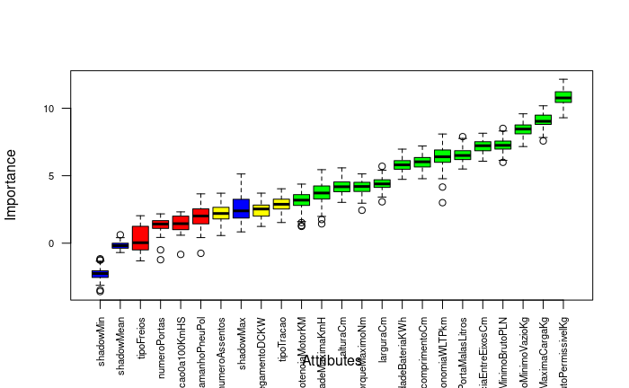

```r
# Visualize as variáveis selecionadas pelo Boruta
plot(boruta_obj, cex.axis = 0.7, las = 2)
```

```r
rm(boruta_obj)
```

```r
X_train <- train_data_normalized[, important_variables]
y_train <- train_data_normalized$mediaConsumoEnergiaKWh100Km

X_test <- test_data_normalized[,important_variables]
y_test <- test_data_normalized$mediaConsumoEnergiaKWh100Km
```

# Passo 07 - Modelagem de Machine Learning

```r
# Função auxiliar para o cálculos das métricas de performance para cada modelo
ml_error <- function( model_name, y, y_hat, R2){
# k = número de variáveis independentes
  e <- y- y_hat
  MAE <- mean(abs(e))
  MAPE <- mean(abs((e)/y)*100)
  MSE <- mean(e^2)
  RMSE <- sqrt(MSE)

  return(data.frame('Model Name' = model_name, MAE = MAE, MAPE = MAPE, MSE = MSE, RMSE = RMSE))
}
```

## 7.1 Modelo de Regressão Linear

```r
# model
modelo_lr <- lm(y_train ~ ., data = X_train)

# prediction
yhat_lr = predict(modelo_lr, newdata = X_test)

# performance
lr_result = ml_error( 'Linear Regression', y_test, yhat_lr)
lr_result
```

| Model.Name | MAE | MAPE | MSE | RMSE |
| --- | --- | --- | --- | --- |
| Linear Regression | 2.076462 | 10.73705 | 9.226348 | 3.03749 |

```r
# model
modelo_lrr <- glmnet(as.matrix(X_train), y_train, alpha = 1)

# prediction
yhat_lrr = predict(modelo_lrr, newx = as.matrix(X_test), s= 0.01)

# performance
lrr_result = ml_error( 'Linear Regression - Ridge', y_test, yhat_lrr)
lrr_result
```

| Model.Name | MAE | MAPE | MSE | RMSE |
| --- | --- | --- | --- | --- |
| Linear Regression - Ridge | 1.975674 | 10.28498 | 8.206758 | 2.864744 |

## 7.3 Modelo de Árvore de Decisão

```r
# Construir o modelo de regressão com rpart
modelo_ad <- rpart(y_train ~ ., data = X_train)

# prediction
yhat_ad= predict(modelo_ad, newdata = X_test)

# performance
ad_result = ml_error( 'Decision Tree', y_test, yhat_ad)
ad_result
```

| Model.Name | MAE | MAPE | MSE | RMSE |
| --- | --- | --- | --- | --- |
| Decision Tree | 1.617262 | 7.501639 | 8.896838 | 2.982757 |

## 7.4 Modelo Random Forest

```r
modelo_rf <- randomForest(y_train ~ ., data = X_train)

# prediction
yhat_rf= predict(modelo_rf, newdata = X_test)

# performance
rf_result = ml_error( 'Random Forest', y_test, yhat_rf)
rf_result
```

| Model.Name | MAE | MAPE | MSE | RMSE |
| --- | --- | --- | --- | --- |
| Random Forest | 1.87033 | 9.079062 | 8.283471 | 2.878102 |

```r
NA
```

## 7.5 Modelo SVM

```r
# Treinamento do modelo SVM com valores padrão
modelo_svm <- svm(y_train ~ ., data = X_train,
                  type = 'eps-regression',
                  kernel = 'linear',
                  C = 1,
                  epsilon = 0.1)

# Fazer previsões nos dados de treinamento
yhat_svm <- predict(modelo_svm, X_test)

# performance
svm_result = ml_error( 'SVM', y_test, yhat_svm)
svm_result
```

| Model.Name | MAE | MAPE | MSE | RMSE |
| --- | --- | --- | --- | --- |
| SVM | 2.073125 | 10.77034 | 10.0009 | 3.162419 |

```r
NA
```

## 7.6 Comparação de Desempenho

```r
resultados <- rbind(lr_result, lrr_result, ad_result, rf_result, svm_result)
resultados[order(resultados$RMSE), ]
```

|  | Model.Name | MAE | MAPE | MSE | RMSE |
| --- | --- | --- | --- | --- | --- |
| 2 | Linear Regression - Ridge | 1.975674 | 10.284977 | 8.206758 | 2.864744 |
| 4 | Random Forest | 1.870330 | 9.079062 | 8.283471 | 2.878102 |
| 3 | Decision Tree | 1.617262 | 7.501639 | 8.896838 | 2.982757 |
| 1 | Linear Regression | 2.076462 | 10.737045 | 9.226348 | 3.037490 |
| 5 | SVM | 2.073125 | 10.770340 | 10.000897 | 3.162419 |

```r
NA
```

# Passo 08 - Tradução e Interpretação do Erro

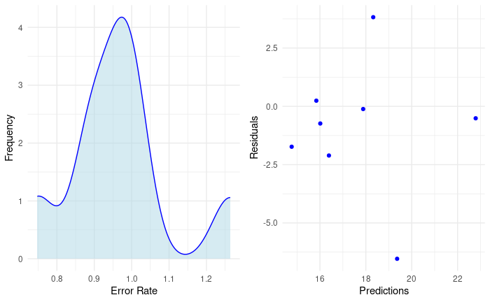

```r
resultadoFinal <- as.data.frame(cbind(y_test, yhat_lrr))
names(resultadoFinal) <- c('mediaConsumoEnergiaKWh100Km', 'predictions')


resultadoFinal <-  mutate(resultadoFinal, residuals = predictions - mediaConsumoEnergiaKWh100Km,
                                          error_rate = predictions/mediaConsumoEnergiaKWh100Km)

# Plotando os resíduos
p1 <- ggplot(resultadoFinal, aes(x = error_rate)) +
  #geom_histogram(aes(y = after_stat(density)), binwidth = 1, fill = "steelblue", color = "black") +
  geom_density(fill = "lightblue", alpha = 0.5, color = "blue") +
  labs(x = "Error Rate", y = "Frequency") +
  theme_minimal()

p2 <- ggplot(resultadoFinal, aes(x = predictions, y = residuals)) +
  geom_point(color = "blue") +
  labs(x = "Predictions", y = "Residuals") +
  theme_minimal()


# Combine os subplots em uma única plotagem usando a função cowplot::plot_grid
# Organização dos subplots lado a lado
grid.arrange(p1, p2, ncol = 2)
```

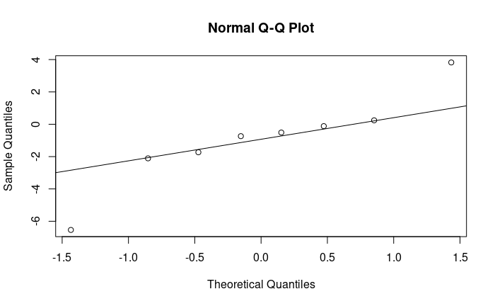

```r
qqnorm(resultadoFinal$residuals)
qqline(resultadoFinal$residuals)
```